# Sprint 0: topology based refacotring and graph stucture

Mike Johnson

2021-02-25

# Goal

The goal is to develop a workflow to modify hydrographic networks to achieve more consistent catchment sizes. This work aims to leverage existing products (e.g, the NHD) that already have a delineated flow and catchment network.

### Walker Data

We use the same sample ‘Walker’ data used in `hygeo`. It appears to be the HUC10-1805000502.

Whatever flowline data is used, it must have a **COMID, TONODE, FROMNODE, STREAMORE, LEVELPATHI, HYDROSEQ**.

The catchment network must have a key **COMID**.

**Area** and **length** can, and should, be calculated within the workflow so are unnecessary.

### Read in Data

More test on data preparation and structure with go on here, but for now we prep the data to make sure all names are lower case, that to, from and comids are represented as JSON, and the graph structure is more explicit.

```r
og_cat <- read_sf("../data/huc1805000502-catchment.gpkg") %>%
   dplyr::select(comid = FEATUREID) %>%
   mutate(areasqkm = as.numeric(set_units(st_area(.), "km2")))

og_fl = read_sf("../data/huc1805000502-flowlines.gpkg") %>%
  prep_flownetwork()
```

Below we see the raw NHD data… there are three main problems:

1. to many small catchments
2. a lot of catchment topology errors
3. complete misalignment between the flow and catchment networks at outlets!

[interactive chart not shown]

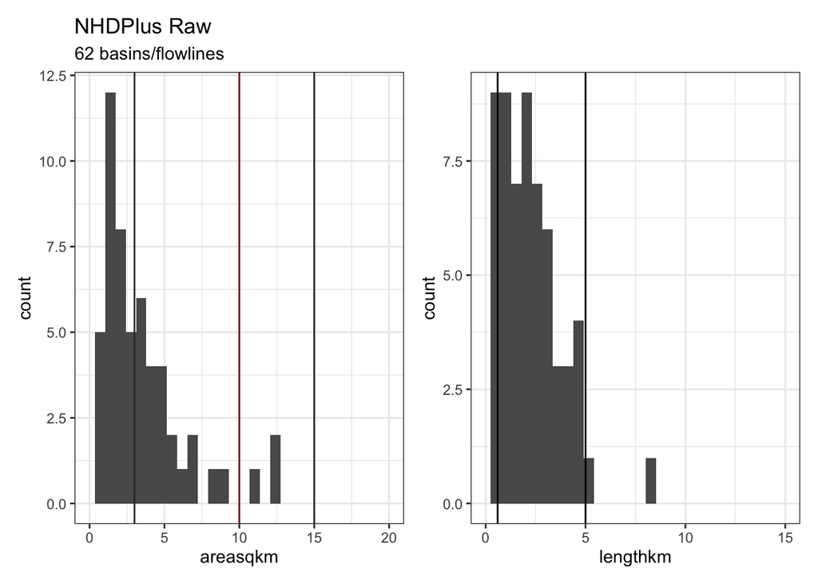

### Catchment consolodation

Our refactoring will focus on catchment aggregation and will *NOT* handle catchment disaggregation.

To start, we identify the headwater inlets in the AOI. Using these as starting points we trace levelpaths downstream aggregating catchments as we go aiming to preserve an “ideal catchment size” without exceeding a maximum catchment size. COMIDs are retained through the aggregation in a JSON notation.

[interactive chart not shown]

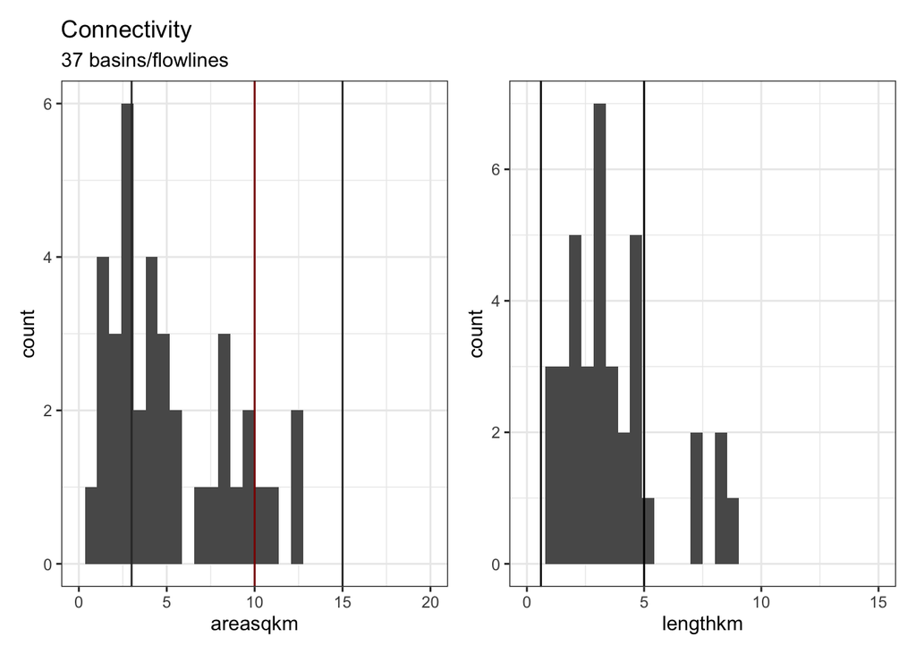

```r
agg_levelpath = aggregate_by_levelpath(og_fl, og_cat,
                                       ideal_size = 10,
                                       max_size = 15, max_length = 10)

mapview(agg_levelpath)
```

After “levelpath aggregation” we begin consuming catchments with sizes less then a minimum threshold, while enforcing a maximum threshold (both user defined). A stream order based logic is applied to aggregate smaller catchments into the larger components.

At the end, only one flow path per catchment is retained and all flowpaths are represented as LINESTRINGS.

```r
agg_size = aggregate_by_size(fl  = agg_levelpath$fl,
                             cat = agg_levelpath$cat,
                             min_size = 3,
                             max_size = 15)

mapview(agg_size)
```

[interactive chart not shown]

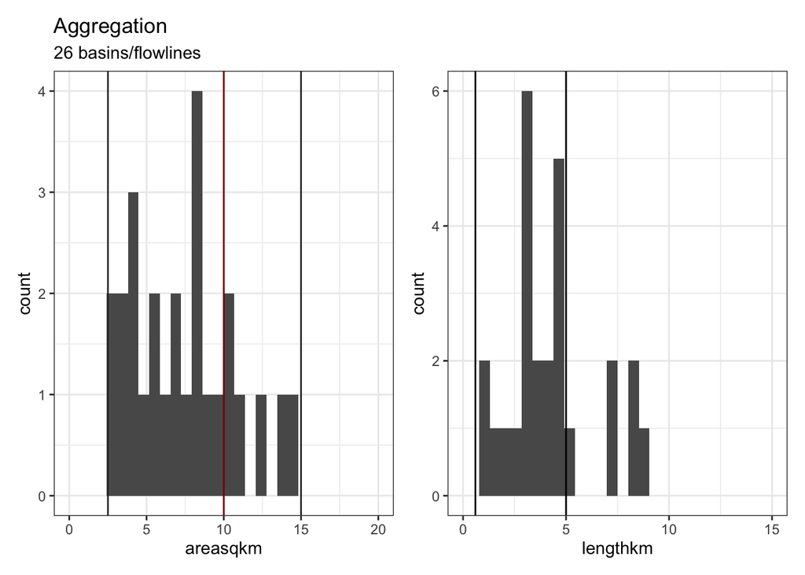

```r
make_plot(agg_size$fl, agg_size$cat, "Aggregation", 2.5,10,15)
```

### {Graph}ing

After the flowline and catchment modifications, we need to re-create the network structure. We do this by identifying the junctions, treating them all as nexus’, and establishing a hierarchy of flow between nexi, flow paths, and respective catchments.

```r
nex_flow  = nexus_flow_graph(fl = agg_size$fl, cat = agg_size$cat)
mapview(nex_flow)
```

[interactive chart not shown]

### Collapsing junctions

In some cases small flow paths can exist, as can basins that *could* be aggregated. As one final pass we look to collapse any two-junction nexi, either into the nearest three-junction nexi (defined by a threshold, km), or by collapsing basins with a single transfer/junction into a single basin if less then the user define max_size.

```r
junctions = collapse_junctions(nex_flow, og_cat, threshold = 1, max_size = 15)
mapview(junctions)
```

[interactive chart not shown]

# Fix Edges

This is the first topology fix. It treats the flowline junctions as “truth” and modifies the catchment vector topology such so there is agreement between the catchment and flowpath network outlets.

There are areas of the NHD where a flowline crosses a catchment boundary, in some cases this results in a chunk of a catchment belonging to a catchment that is not part if the associated flowpath. This section seeks to split, reunite and modify these areas.

[interactive chart not shown]

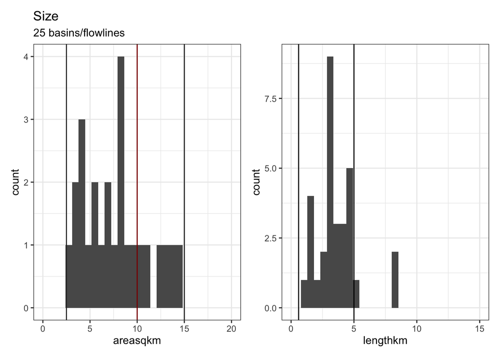

```r
topo = topology_doctor(junctions)
mapview(topo)
```

Returning to our three problems (in this basin at least!)

1. to many small catchments
2. a lot of catchment topology errors
3. complete misalignment between the flow and catchment networks at outlets!

# End of sprint 0